# Bon_Jovi_report

Author

Zoja Pleteršek

# BON JOVI

*“And the truth is, Baby, you’re all that I need”*

Bon Jovi

## THEIR STORY

Bon Jovi, the iconic American rock band, first rocked onto the scene from Sayreville, New Jersey, in 1983. Fronted by the charismatic Jon Bon Jovi, they soared to global fame with their third album, “Slippery When Wet” (1986), unleashing chart-toppers like “Livin’ on a Prayer” and “You Give Love a Bad Name.” This breakthrough solidified their place at the forefront of the late 1980s rock scene.

Navigating challenges in the late ’90s, the band staged a triumphant comeback with the 2000 release of “Crush,” featuring the anthemic “It’s My Life.”

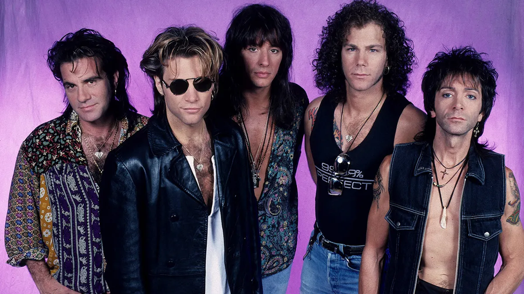

[*Bon Jovi, “Keep the Faith,” in 1992, from left, Tico Torres, Jon Bon Jovi, Richie Sambora, David Bryan and Alec John Such. (Mark Weiss)*](https://www.foxnews.com/entertainment/bon-jovi-iconic-rock-band)

## THEIR ALBUMS

This starting section offers a glimpse into the Bon Jovi group’s musical journey over the years. It’s your ticket to deciphering which albums was influenced by that unmistakable 00s vibe and which ones transport you right back to the electrifying eras of the ’80s and ’90s.

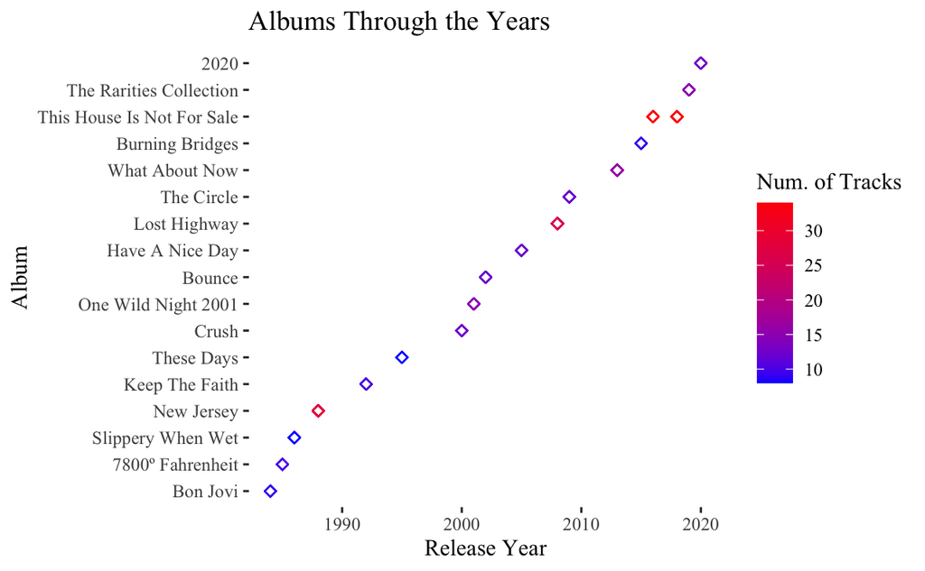

### ALBUM ANALYSIS

In the upcoming section, we’re diving into a comparison of song tempo, energy, danceability, and liveness. Consider it your personalized guide to pinpointing the albums that align perfectly with your preferences in these musical dimensions.

#### Tempo

Taking a closer look, we notice a delightful range of tempos across Bon Jovi’s albums. “These Days” opts for a relatively leisurely pace, embracing a mellow vibe, whereas their debut album “Bon Jovi” sets the stage with a spirited and upbeat tempo.

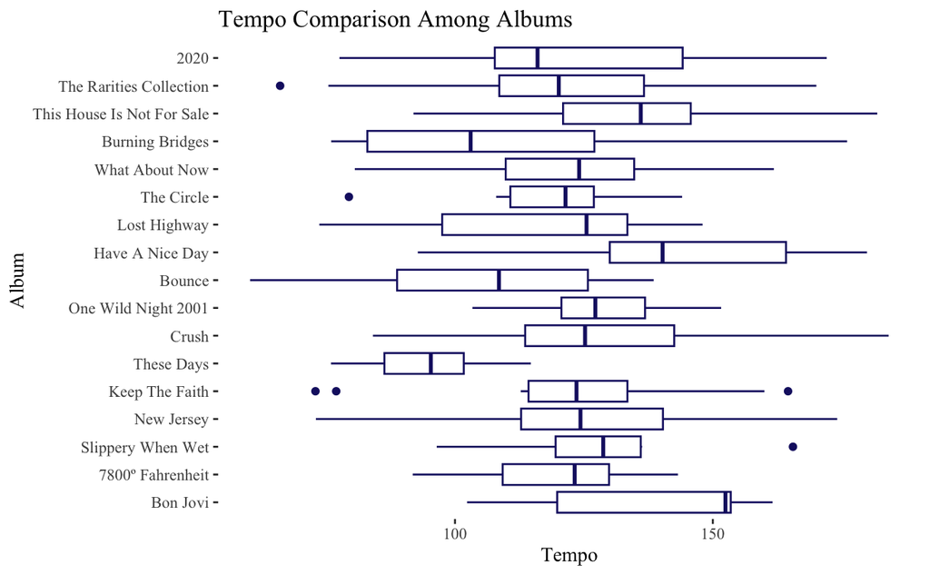

#### Energy

The energy levels in almost all the albums are cranked up to the max—just the way we like it. The only thing that changes is the delightful variation of energy within each album

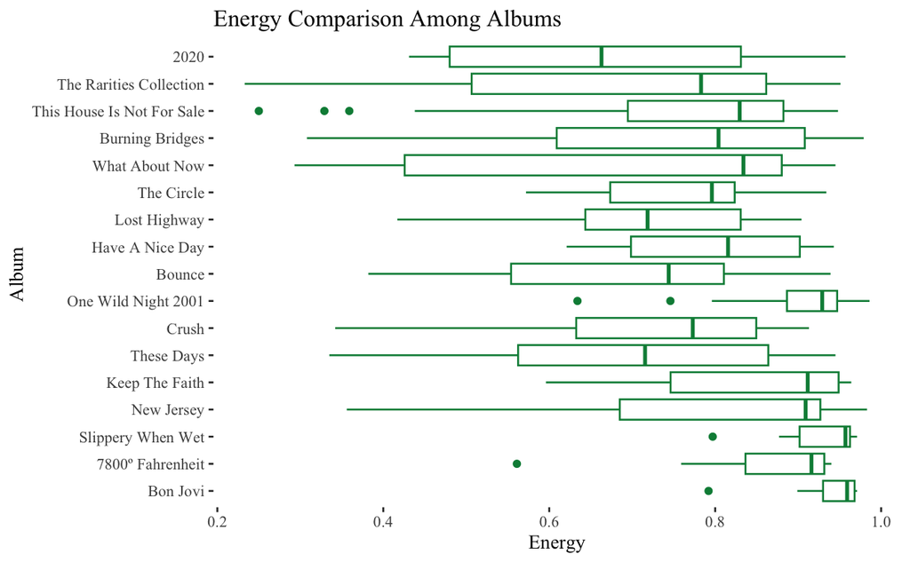

#### Danceability

Let’s just put it out there: no matter which Bon Jovi album you choose, you’re in for a dance party!

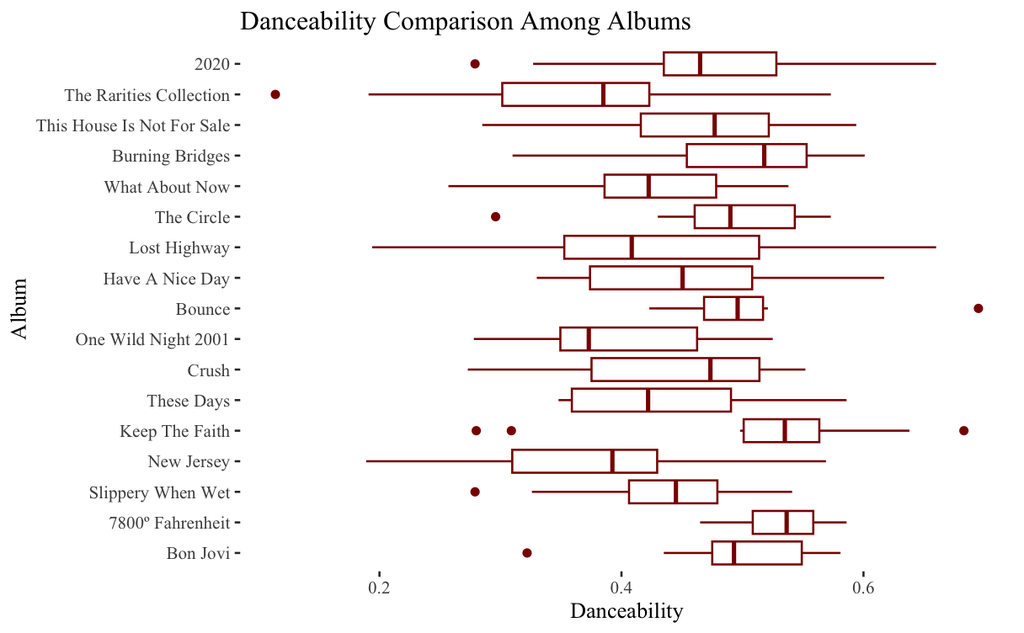

#### Loudness

As expected from a rock band, the music cranks up to full in all their albums! Get ready for some seriously loud tunes that’ll have you rocking out in no time!

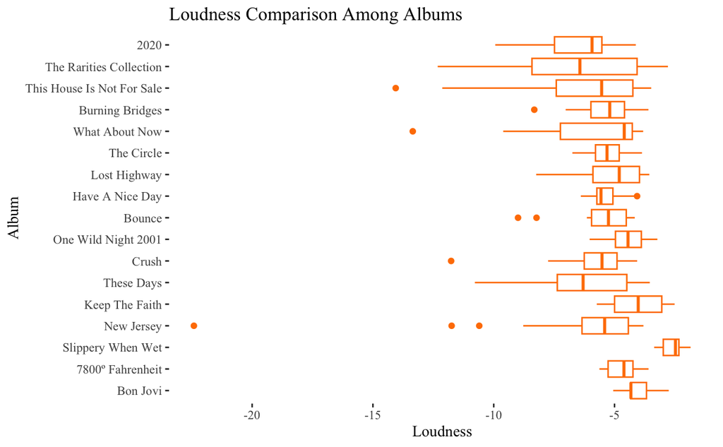

## ANALYSING SONGS

#### Danceability and Energy

And here, my dears, unfolds your ultimate guide to curate the perfect soundtrack for your upcoming festivities.

So, envision your soirée: are you leaning towards the tranquil ambiance of a wine-tasting affair? Opt for melodies with low danceability and a serene energy. Perhaps you’re feeling a bit groovy—then, venture into the realm of higher danceability. But if it’s a dynamic and spirited fiesta where the dance floor becomes your stage, dive into the upper right quadrant of tunes. And for those moments when you crave an energy boost, be it for a run rather than a dance, seek out those with high energy and a touch lower on the danceability scale.

A mere hover over the songs after you click on the link will reveal which ones perfectly align with your plans!

Click Here

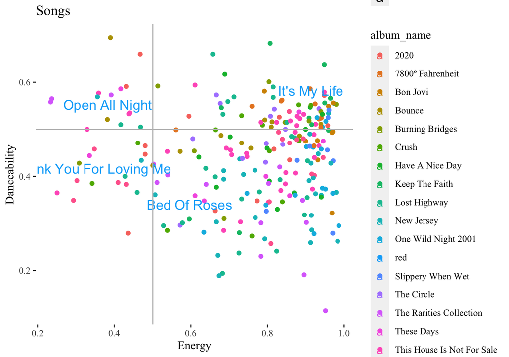

[Open All Night](https://www.youtube.com/watch?v=TxuXBj3EjOs)

[video not shown]

[Its My Lif](https://www.youtube.com/watch?v=vx2u5uUu3DE)e

[video not shown]

[Bed Of Roses](https://www.youtube.com/watch?v=RdkWFaZc3JY)

[video not shown]

[Thank You For Loving Me](https://www.youtube.com/watch?v=nddTokI9hHY)

[video not shown]

#### Valence and Energy

Let’s not overlook the profound influence that music wields over our emotions—it serves as a potent force, capable of both shaping and affirming our feelings.

If you’re in the mood for some upbeat tunes, direct your search to the upper right quadrant, where songs boast high valence and energy. Should your happiness lean towards tranquility, venture down to the quadrant below. There are moments when we seek a melody that resonates with our sorrows, providing solace and making us feel less alone. In such times, explore songs characterized by low energy and valence. And for those in pursuit of soothing, gentle tunes, opt for selections with higher valence.

In essence, simply click on the link and hover over and curate your ideal playlist.

Click Here

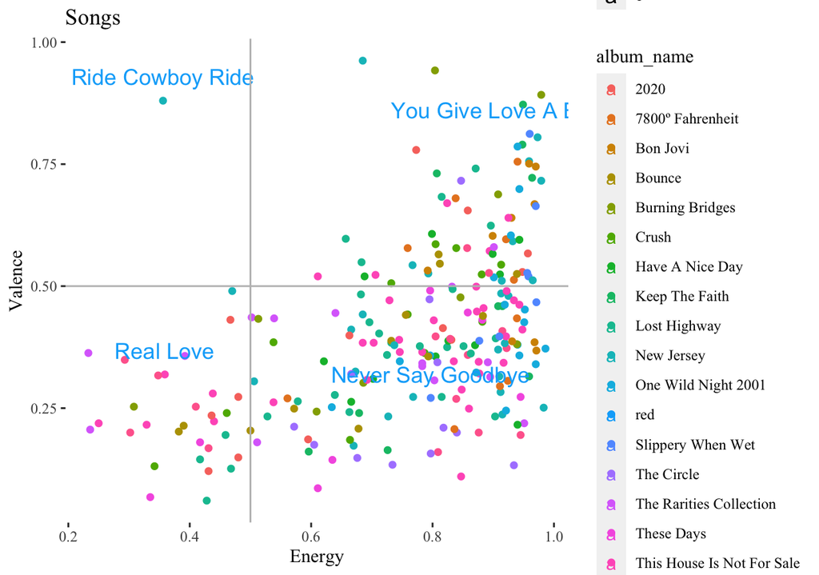

[Ride Cowboy Ride](https://www.youtube.com/watch?v=WwWiP_d2XYA)

[video not shown]

[You Give Love A Bad Name](https://www.youtube.com/watch?v=Aqc3VTpz9HQ)

[video not shown]

[Never Say Goodbye](https://www.youtube.com/watch?v=IDCFX5NShlE)

[video not shown]

[Real Love](https://www.youtube.com/watch?v=9aZFFCgYPdk)

[video not shown]

### CODE

```r
library(plotly)
library(ggplot2)
library(dplyr)
library(grid)
library(stringr)
library(shiny)

df <- read.csv("Bon_Jovi.csv")

df <- df |> distinct(track_name, .keep_all = TRUE)
df$album_name <- ifelse(df$album_name %in% c("New Jersey (Deluxe Edition)", "New Jersey"), "New Jersey",
                 ifelse(df$album_name %in% c("This House Is Not For Sale (Deluxe)", "This House Is Not For Sale (Live From The London Palladium)", "This House Is Not For Sale"), "This House Is Not For Sale",
                  ifelse(df$album_name %in% c("2020 (Deluxe)", "2020"), "2020",   df$album_name)))

#creating additional variable that counts the tracks in each album for better overview
df <- df %>%
  group_by(album_name) %>%
  mutate(song_count = (n()))

#changing duration into minutes for clarity and feasability
df$duration <- df$duration_ms/(1000 * 60)
```

```r
print(ggplotly(ggplot(df, aes(x = energy, y = valence, color = album_name, text = track_name)) +
  geom_point() +
  labs(x = "Energy", y = "Valence", title = "Songs", ) +
  geom_vline(xintercept = 0.5, color= "grey") +
  geom_hline(yintercept = 0.5, color= "grey") +
  theme(
    panel.background = element_rect(fill = "transparent"),
    text = element_text(family = "Times New Roman")
    )))
```

[output not shown]

```r
print(ggplotly(ggplot(df, aes(x = energy, y = danceability, color = album_name, text = track_name)) +
  geom_point() +
  labs(x = "Energy", y = "Danceability", title = "Songs", ) +
  geom_vline(xintercept = 0.5, color= "grey") +
  geom_hline(yintercept = 0.5, color= "grey") +
  theme(
    panel.background = element_rect(fill = "transparent"),
    text = element_text(family = "Times New Roman")
    )))
```

[output not shown]

```r
unique(df$album_name)
```

```
 [1] "These Days"                 "Lost Highway"
 [3] "New Jersey"                 "Burning Bridges"
 [5] "Bounce"                     "This House Is Not For Sale"
 [7] "7800º Fahrenheit"           "What About Now"
 [9] "2020"                       "The Rarities Collection"
[11] "One Wild Night 2001"        "Keep The Faith"
[13] "Have A Nice Day"            "Bon Jovi"
[15] "The Circle"                 "Crush"
[17] "Slippery When Wet"
```

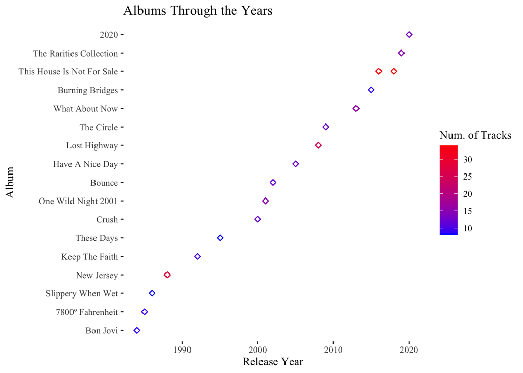

```r
ggplot(df, aes(x = album_release_year, y = reorder(album_name, album_release_year), color = song_count)) +
  geom_point(shape = 5) +
  labs(x = "Release Year", y = "Album", title = "Albums Through the Years") +
  theme(panel.background = element_rect(fill = "transparent"),
        text = element_text(family = "Times New Roman")) +
  scale_color_gradient(low = "blue", high = "red", name = "Num. of Tracks")
```

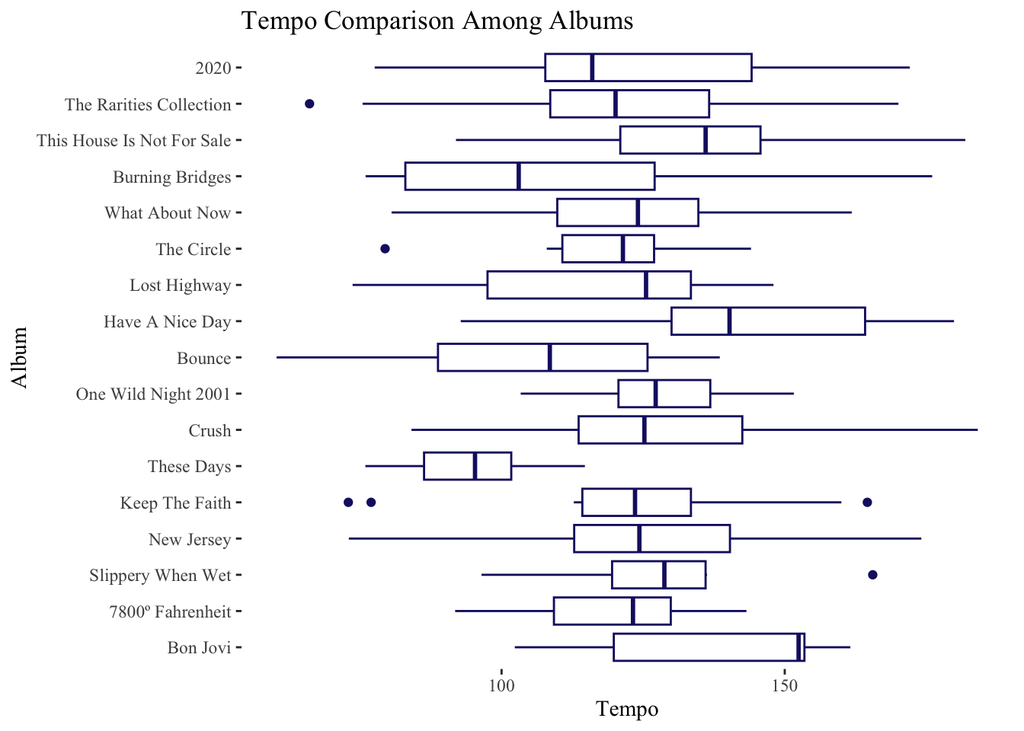

```r
ggplot(df, aes(x = tempo, y = reorder(album_name, album_release_year))) +
  geom_boxplot(color = "Midnight Blue") +
  labs(x = "Tempo", y = "Album", title = "Tempo Comparison Among Albums") +
  theme(panel.background = element_rect(fill = "transparent"),
        text = element_text(family = "Times New Roman"))
```

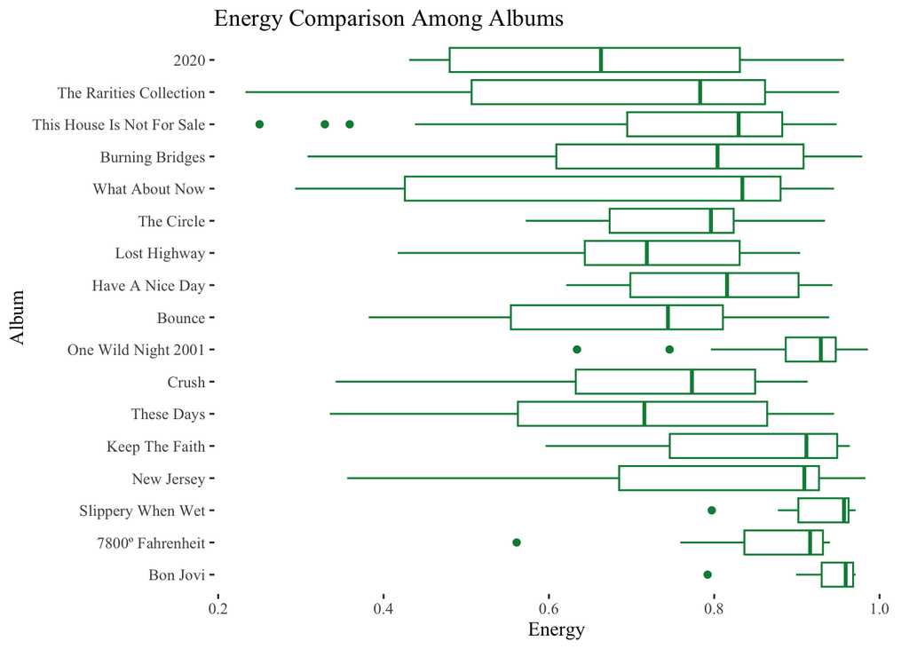

```r
ggplot(df, aes(x = energy, y = reorder(album_name, album_release_year))) +
  geom_boxplot(color = " springgreen4") +
  labs(x = "Energy", y = "Album", title = "Energy Comparison Among Albums")+
  theme(panel.background = element_rect(fill = "transparent"),
        text = element_text(family = "Times New Roman"))
```

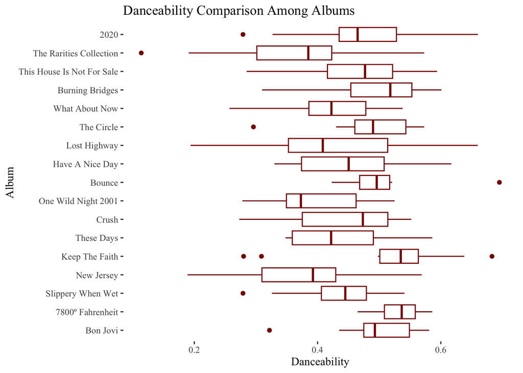

```r
ggplot(df, aes(x = danceability, y = reorder(album_name, album_release_year))) +
  geom_boxplot(color = "darkred")+
  labs(x = "Danceability", y = "Album", title = "Danceability Comparison Among Albums")+
  theme(panel.background = element_rect(fill = "transparent"),
        text = element_text(family = "Times New Roman"))
```

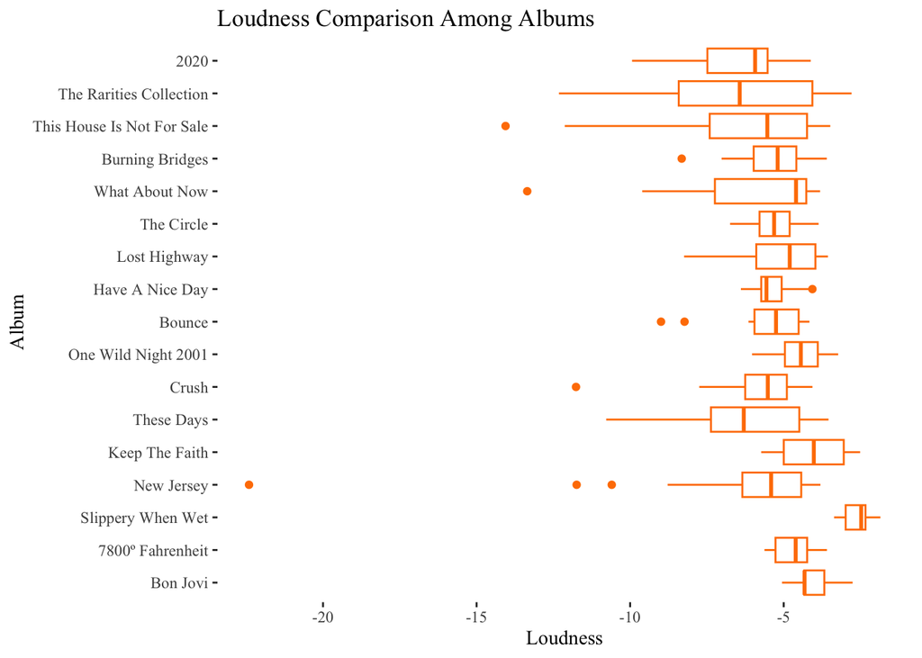

```r
(ggplot(df, aes(x = loudness, y = reorder(album_name, album_release_year))) +
  geom_boxplot(color = "Darkorange1") +
  labs(x = "Loudness", y = "Album", title = "Loudness Comparison Among Albums")+
  theme(panel.background = element_rect(fill = "transparent"),
        text = element_text(family = "Times New Roman")))
```

```r
plot1 <- df |> filter(track_name %in% c("Open All Night", "It's My Life", "Thank You For Loving Me", "Bed Of Roses"))

print(ggplotly(ggplot(df, aes(x = energy, y = danceability, color = album_name, text = track_name)) +
  geom_point() +
  geom_text(data = plot1, aes(label = track_name, color = "red", vjust = -1, size = 1)) +
  labs(x = "Energy", y = "Danceability", title = "Songs", ) +
  geom_vline(xintercept = 0.5, color= "grey") +
  geom_hline(yintercept = 0.5, color= "grey") +
  theme(
    panel.background = element_rect(fill = "transparent"),
    text = element_text(family = "Times New Roman")
    )))
```

```r
plot2 <- df |> filter(track_name %in% c("Ride Cowboy Ride", "You Give Love A Bad Name", "Real Love", "Never Say Goodbye"))

print(ggplotly(ggplot(df, aes(x = energy, y = valence, color = album_name, text = track_name)) +
  geom_point() +
  geom_text(data = plot2, aes(label = track_name, color = "red", vjust = -1, size = 1)) +
  labs(x = "Energy", y = "Valence", title = "Songs", ) +
  geom_vline(xintercept = 0.5, color= "grey") +
  geom_hline(yintercept = 0.5, color= "grey") +
  theme(
    panel.background = element_rect(fill = "transparent"),
    text = element_text(family = "Times New Roman"))))
```

```r
df_extra <- tibble(
  song = df$track_name,
  valence = df$valence,
  energy = df$energy,
  danceability = df$danceability
)
#codes i used to find the songs to display on the graphs
print(df_extra$energy > 0.5 & df_extra$danceability > 0.5)
```

[output not shown]

```r
print(df_extra$energy > 0.5 & df_extra$danceability < 0.5)
```

[output not shown]

```r
print(df_extra$energy < 0.5 & df_extra$danceability > 0.5)
```

[output not shown]

```r
print(df_extra$energy < 0.5 & df_extra$danceability < 0.5)
```

[output not shown]

```r
print(df_extra$energy > 0.5 & df_extra$valence > 0.5)
```

[output not shown]

```r
print(df_extra$energy > 0.5 & df_extra$valence < 0.5)
```

[output not shown]

```r
print(df_extra$energy < 0.5 & df_extra$valence > 0.5)
```

[output not shown]

```r
print(df_extra$energy < 0.5 & df_extra$valence < 0.5)
```

[output not shown]

```r
print(df_extra[247, ])
```

```
# A tibble: 1 × 4
  song                     valence energy danceability
  <chr>                      <dbl>  <dbl>        <dbl>
1 You Give Love A Bad Name   0.812   0.96        0.541
```

```r
#You Give Love A Bad Name   0.812   0.96    0.541
print(df_extra[22, ])
```

```
# A tibble: 1 × 4
  song         valence energy danceability
  <chr>          <dbl>  <dbl>        <dbl>
1 Bed Of Roses   0.161  0.596        0.309
```

```r
#Bed Of Roses   0.161   0.596   0.309
print(df_extra[195, ])
```

```
# A tibble: 1 × 4
  song                    valence energy danceability
  <chr>                     <dbl>  <dbl>        <dbl>
1 Thank You For Loving Me   0.131  0.342        0.385
```

```r
# Thank You For Loving Me   0.131   0.342   0.385
print(df_extra[137, ])
```

```
# A tibble: 1 × 4
  song              valence energy danceability
  <chr>               <dbl>  <dbl>        <dbl>
1 Never Say Goodbye   0.271  0.797        0.326
```

```r
# Never Say Goodbye 0.271   0.797   0.326
print(df_extra[93, ])
```

```
# A tibble: 1 × 4
  song         valence energy danceability
  <chr>          <dbl>  <dbl>        <dbl>
1 It's My Life   0.544  0.913        0.551
```

```r
#It's My Life   0.544   0.913   0.551
print(df_extra[153, ])
```

```
# A tibble: 1 × 4
  song      valence energy danceability
  <chr>       <dbl>  <dbl>        <dbl>
1 Real Love   0.319  0.359        0.577
```

```r
#Real Love  0.319   0.359   0.577
print(df_extra[150, ])
```

```
# A tibble: 1 × 4
  song           valence energy danceability
  <chr>            <dbl>  <dbl>        <dbl>
1 Open All Night   0.202  0.382        0.521
```

```r
#Open All Night 0.202   0.382   0.521
print(df_extra[157, ])
```

```
# A tibble: 1 × 4
  song             valence energy danceability
  <chr>              <dbl>  <dbl>        <dbl>
1 Ride Cowboy Ride    0.88  0.356        0.569
```

```r
#Ride Cowboy Ride   0.88    0.356   0.569
```